# Formula Interface for ggplot2

## Positions and Stats

### Positions

`position_dodge()`, `position_jitter()`, and `position_jitterdodge()` can be used to adjust the positions at which glyphs are placed. Jittering adds some random noise and can be useful when many observations have the same value. Dodging moves groups of glyphs a fixed difference to make it easier to distinguish the groups.

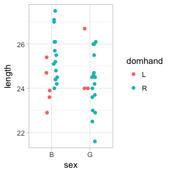

```r
gf_point(length ~ sex, color = ~ domhand, data = KidsFeet,
         position = position_jitterdodge(jitter.width = 0.2, dodge.width = 0.4))
```

### Stats

A **stat** is a transformation that is applied to the data before a plot is generated. Several of the plots we have seen have made use of stats.

- `gf_histogram()` uses `stat_bin()` to bin the data and count the number of observations in each bin. It is equivalent to

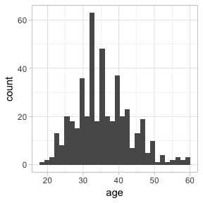

```r
gf_bar( ~ age, data = HELPrct, stat = "bin")
```

* `gf_boxplot()` uses `stat_boxplot()` to compute the five-number summary on which the boxplot is based.

- `gf_violin()`, `gf_density()`, and `gf_density2d()` use stats to compute a sequence of points along an estimated density. It is these points, and the not the raw data that are used to create the plot.

Mostly, the stats selected by default are just the ones you need. But sometimes it is useful to select a different stat. The `stat_summary()` and `stat_summary_bin()` stats are particularly useful in this respect. These stats use a function to aggregate over unique values of `x` or over bins of `x` values and save the user needing to do that data transformation manually.

The default function applied in each group is `mean_se()`, which computes the mean (and the mean plus and minus one standard error) This makes it simple to create an “interaction plot”.

```r
gf_jitter(length ~ sex, color = ~domhand, data = KidsFeet,
          width = 0.1, height = 0) %>%
  gf_line(length ~ sex, color = ~domhand, data = KidsFeet,
          group = ~domhand, stat="summary")
```

```
## No summary function supplied, defaulting to `mean_se()
```

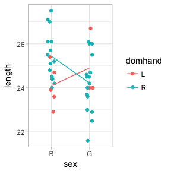

The other two values computed by `mean_se()` are available as `..ymin..` and `..ymax..`.

```r
gf_jitter(length ~ sex, color = ~domhand, data = KidsFeet,
          width = 0.1, height = 0, alpha = 0.3) %>%
  gf_pointrange(length + ..ymin.. + ..ymax.. ~ sex,
                color = ~domhand, data = KidsFeet,
                group = ~domhand, stat="summary")
```

```
## No summary function supplied, defaulting to `mean_se()
```

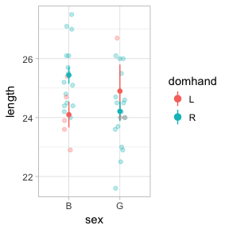

Custom functions can be used by defining `fun.y`, `fun.ymin`, and `fun.ymax`, or a single function `fun.data` that returns a data frame with variables named `y`, `ymin`, and `ymax`.

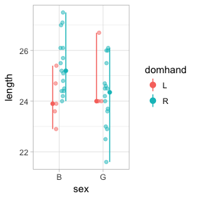

```r
gf_point(length ~ sex, color = ~domhand, data = KidsFeet,
          width = 0.1, height = 0, alpha = 0.5,
          position = position_jitterdodge(jitter.width = 0.2, dodge.width = 0.3)) %>%
  gf_pointrange(length + ..ymin.. + ..ymax.. ~ sex,
                color = ~domhand, data = KidsFeet,
                group = ~domhand, stat="summary",
                fun.y = median, fun.ymin = min, fun.ymax = max,
                position = position_dodge(width = 0.6))
```

## Chaining to create complex plots

### Multiple layers

Often it is useful to overlay multiple layers onto a single plot. This can be done by chaining them with `%>%`, the “then” operator from `magrittr`. The `data` argument can be omitted if the new layers uses the same data as the first layer in the chain.

The following plot illustrates how histograms and frequency polygons are related.

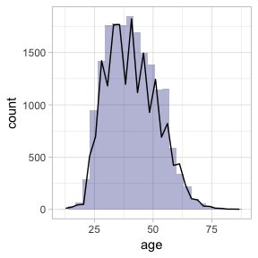

```r
gf_histogram( ~ age, data = Runners, alpha = 0.3, fill = "navy") %>%
  gf_freqpoly( ~ age)
```

A 2-d density plot can be augmented with a scatterplot.

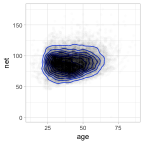

```r
gf_density_2d(net ~ age, data = Runners) %>%
  gf_point(net ~ age, alpha = 0.01)
```

### Faceting

The `ggplot2` system allows you to make subplots — called “facets” — based on the values of one or two categorical variables. This is done by chaining with `gf_facet_grid()` or `gf_facet_wrap()`. These functions use formulas to specify which variable(s) are to be used for faceting.

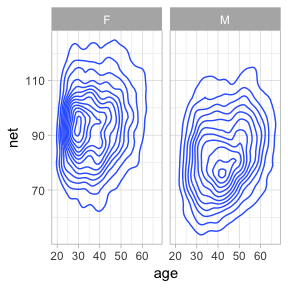

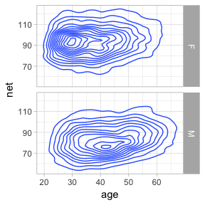

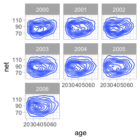

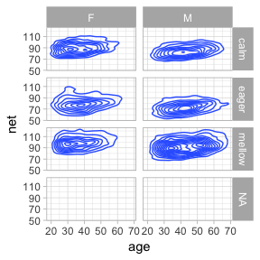

```r
gf_density_2d(net ~ age, data = Runners) %>% gf_facet_grid( ~ sex)
# the dot here is a bit strange, but required to make a valid formula
gf_density_2d(net ~ age, data = Runners) %>% gf_facet_grid( sex ~ .)
gf_density_2d(net ~ age, data = Runners) %>% gf_facet_wrap( ~ the_year)
gf_density_2d(net ~ age, data = Runners) %>% gf_facet_grid(start_position ~ sex)
```

One use of facets is to create side-by-side plots of different data sources.  
First we merge the data into a single data frame with a variable to indicate the original data source. Then we use facets to separate the data into the various sources for the display. The redundant use of the `y` and `color` attributes for temperature makes it easier to compare across facets.

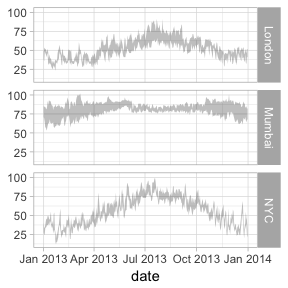

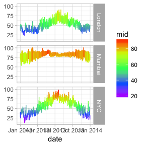

```r
require(weatherData)
Temps <- NewYork2013 %>% mutate(city = "NYC") %>%
  bind_rows(Mumbai2013 %>% mutate(city = "Mumbai")) %>%
  bind_rows(London2013 %>% mutate(city = "London")) %>%
  mutate(date = lubridate::date(Time),
         month = lubridate::month(Time)) %>%
  group_by(city, date) %>%
  summarise(
    hi = max(Temperature, na.rm = TRUE),
    lo = min(Temperature, na.rm = TRUE),
    mid = (hi + lo)/2
  )
gf_ribbon(lo + hi ~ date, data = Temps, alpha = 0.3) %>%
  gf_facet_grid(city ~ .)

gf_linerange(lo + hi ~ date, color = ~ mid, data = Temps) %>%
  gf_facet_grid(city ~ .) %>%
  gf_refine(scale_colour_gradientn(colors = rev(rainbow(5))))
```

### Global plot adjustments

There are a number of things we may want to do to the entire plot – adjusting labels, colors, fonts, etc. `ggformula` provides wrappers to the `ggplot2` functions for this so that the chaining syntax can be used.

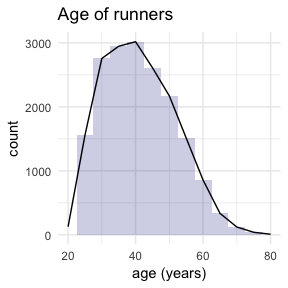

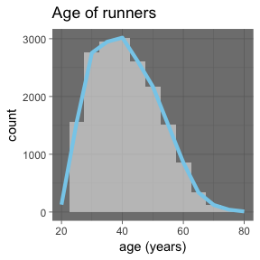

```r
gf_histogram( ~ age, data = Runners, alpha = 0.2, fill = "navy",
              binwidth = 5) %>%
  gf_freqpoly( ~ age, binwidth = 5) %>%
  gf_labs(x = "age (years)", title = "Age of runners") %>%
  gf_lims(x = c(20, 80)) %>%
  gf_theme(theme = theme_minimal())
gf_histogram( ~ age, data = Runners, alpha = 0.5, fill = "white",
              binwidth = 5) %>%
  gf_freqpoly( ~ age, color = "skyblue", binwidth = 5, size = 1.5) %>%
  gf_labs(x = "age (years)", title = "Age of runners") %>%
  gf_lims(x = c(20, 80)) %>%
  gf_theme(theme = theme_dark())
```